# Index Tracking Portfolio

- Required Libraries
- SSL Error
- Obtaining Historical Data: DIA and It's Components
- Visualizing DIA Prices vs Each Company's Prices
  - Normalizing Data
  - Annual Return and Annual Volatility
- Exploratory Data Analysis
- Index Tracking Intro
  - The Plan

Press the button to see the code behind everything or just view the notebook with code hidden:

## Required Libraries

1. Python: pandas, numpy, matplotlib, seaborn
2. [yfinance Library](https://pypi.org/project/yfinance/)

```python
import yfinance as yf
import pandas as pd
import matplotlib.pyplot as plt
import numpy as np
import seaborn as sns
plt.style.use('seaborn')
```

## SSL Error

Depending on the version of jupyter/ pandas you have, you may run into a SSL error if you use:

```
pd.read_html()
```

to fetch table data. To fix this, please refer to the [link here](https://moreless.medium.com/how-to-fix-python-ssl-certificate-verify-failed-97772d9dd14c).

```python
import os, ssl

if (not os.environ.get('PYTHONHTTPSVERIFY', '') and
getattr(ssl, '_create_unverified_context', None)):
    ssl._create_default_https_context = ssl._create_unverified_context
```

## Obtaining Historical Data: DIA and It's Components

We scraped the [DJIA Wikipedia page](https://en.wikipedia.org/wiki/Dow_Jones_Industrial_Average) for the 30 companies that make it consists of and save it to a data frame called "dow_companies" after adjusting data types and renaming some columns. Although we are using the DIA ETF, this ETF's holdings are exactly those 30 companies that make up the DJIA!

Note that DIA holds a total of 32 positions (including U.S. Dollar), but for the purposes of this project we will be excluding U.S. dollar and Kyndryl Holdings Inc (KD), since the latter just began public trading on Nov. 4th, 2021 (won't have enough data for us to work with). The full list of DIA holdings can be downloaded [from the website here](https://www.ssga.com/us/en/intermediary/etfs/funds/spdr-dow-jones-industrial-average-etf-trust-dia) under the section "Holdings".

This is what our data frame looks like:

```python
# The table we need when we need when we scraped the website
# for tabular data is in position 1 of the list that
# pd.read_html automatically assigns it to:
dow_companies = pd.read_html('https://en.wikipedia.org/wiki/Dow_Jones_Industrial_Average')[1]

# We need all rows, but just the first 5 columns
dow_companies = dow_companies.iloc[:,:5].copy()

# Do not want whitespace in column name
dow_companies.rename(columns = {"Date added":"Date_Added", "Symbol":"Ticker"}, inplace = True)

# Changing the datatype specifically to "datetime64" rather than just "object" (text)
dow_companies.Date_Added = pd.to_datetime(dow_companies.Date_Added)

# Adding all tickers to a list for later use
ticker_list = dow_companies.Ticker.to_list()

# Saving it to a .csv file for future use
dow_companies.to_csv('dow_companies_info.csv', index = False) # drop index with 0-29

dow_companies
```

|  | Company | Exchange | Ticker | Industry | Date_Added |
| --- | --- | --- | --- | --- | --- |
| 0 | 3M | NYSE | MMM | Conglomerate | 1976-08-09 |
| 1 | American Express | NYSE | AXP | Financial services | 1982-08-30 |
| 2 | Amgen | NASDAQ | AMGN | Biopharmaceutical | 2020-08-31 |
| 3 | Apple Inc. | NASDAQ | AAPL | Information technology | 2015-03-19 |
| 4 | Boeing | NYSE | BA | Aerospace and defense | 1987-03-12 |
| 5 | Caterpillar Inc. | NYSE | CAT | Construction and Mining | 1991-05-06 |
| 6 | Chevron Corporation | NYSE | CVX | Petroleum industry | 2008-02-19 |
| 7 | Cisco Systems | NASDAQ | CSCO | Information technology | 2009-06-08 |
| 8 | The Coca-Cola Company | NYSE | KO | Soft Drink | 1987-03-12 |
| 9 | Dow Inc. | NYSE | DOW | Chemical industry | 2019-04-02 |
| 10 | Goldman Sachs | NYSE | GS | Financial services | 2013-09-20 |
| 11 | The Home Depot | NYSE | HD | Home Improvement | 1999-11-01 |
| 12 | Honeywell | NASDAQ | HON | Conglomerate | 2020-08-31 |
| 13 | IBM | NYSE | IBM | Information technology | 1979-06-29 |
| 14 | Intel | NASDAQ | INTC | Semiconductor industry | 1999-11-01 |
| 15 | Johnson & Johnson | NYSE | JNJ | Pharmaceutical industry | 1997-03-17 |
| 16 | JPMorgan Chase | NYSE | JPM | Financial services | 1991-05-06 |
| 17 | McDonald's | NYSE | MCD | Food industry | 1985-10-30 |
| 18 | Merck & Co. | NYSE | MRK | Pharmaceutical industry | 1979-06-29 |
| 19 | Microsoft | NASDAQ | MSFT | Information technology | 1999-11-01 |
| 20 | Nike, Inc. | NYSE | NKE | Apparel | 2013-09-20 |
| 21 | Procter & Gamble | NYSE | PG | Fast-moving consumer goods | 1932-05-26 |
| 22 | Salesforce | NYSE | CRM | Information technology | 2020-08-31 |
| 23 | The Travelers Companies | NYSE | TRV | Insurance | 2009-06-08 |
| 24 | UnitedHealth Group | NYSE | UNH | Managed health care | 2012-09-24 |
| 25 | Verizon Communications | NYSE | VZ | Telecommunication | 2004-04-08 |
| 26 | Visa Inc. | NYSE | V | Financial services | 2013-09-20 |
| 27 | Walgreens Boots Alliance | NASDAQ | WBA | Retailing | 2018-06-26 |
| 28 | Walmart | NYSE | WMT | Retailing | 1997-03-17 |
| 29 | The Walt Disney Company | NYSE | DIS | Broadcasting and entertainment | 1991-05-06 |

Afterwards, we used the yfinance library to fetch historical data of the [DIA ETF](https://www.investopedia.com/etfs/etfs-track-dow/).

In short, "DIA is the ETF for investors seeking to replicate the performance of the Dow" (Investopedia). DIA's holdings consists of the 30 companies that make up the DJIA.

For the purposes of this project, just grabbing the past ~15 years of data should suffice. After we obtained the data we assigned the data frame to "dia".

We also created a copy of the "dia" data frame that only contains it's closing prices and assigned it to "dia__close_price_only".

```python
# Obtaining historical data from yfinance
dia = yf.download("DIA", start = "2007-01-01", end = "2021-10-01")
dia.to_csv('dia.csv') # Saving as .csv file for later use

# Showing the DIA data frame
print('\n')
print('\033[4mDIA Data Frame:\033[0m')
display(dia)

print('\n')
print('\n')

# We only need the Closing prices
dia_close_price_only = dia.Close.to_frame().copy()
print('\033[4mDIA Closing Prices Only:\033[0m')
dia_close_price_only.rename(columns = {'Close':'DIA_Closing_Prices'}, inplace = True)
display(dia_close_price_only)
```

```
[*********************100%***********************]  1 of 1 completed


DIA Data Frame:
```

| Date | Open | High | Low | Close | Adj Close | Volume |
| --- | --- | --- | --- | --- | --- | --- |
| 2007-01-03 | 125.160004 | 125.680000 | 123.879997 | 124.470001 | 87.902351 | 11525000 |
| 2007-01-04 | 124.480003 | 124.949997 | 123.889999 | 124.680000 | 88.050682 | 10318700 |
| 2007-01-05 | 124.470001 | 124.500000 | 123.519997 | 123.739998 | 87.386803 | 9389000 |
| 2007-01-08 | 123.870003 | 124.389999 | 123.250000 | 124.139999 | 87.669289 | 8092400 |
| 2007-01-09 | 124.339996 | 124.570000 | 123.419998 | 124.070000 | 87.619835 | 7438700 |
| ... | ... | ... | ... | ... | ... | ... |
| 2021-09-24 | 346.500000 | 348.429993 | 346.309998 | 347.869995 | 347.753418 | 3121600 |
| 2021-09-27 | 348.290009 | 350.500000 | 348.170013 | 348.609985 | 348.493164 | 3426000 |
| 2021-09-28 | 347.309998 | 347.820007 | 342.410004 | 342.920013 | 342.805115 | 7493800 |
| 2021-09-29 | 343.869995 | 345.670013 | 342.880005 | 343.769989 | 343.654785 | 4116600 |
| 2021-09-30 | 345.079987 | 345.440002 | 338.109985 | 338.290009 | 338.176636 | 7895200 |

3713 rows × 6 columns

```
DIA Closing Prices Only:
```

| Date | DIA_Closing_Prices |
| --- | --- |
| 2007-01-03 | 124.470001 |
| 2007-01-04 | 124.680000 |
| 2007-01-05 | 123.739998 |
| 2007-01-08 | 124.139999 |
| 2007-01-09 | 124.070000 |
| ... | ... |
| 2021-09-24 | 347.869995 |
| 2021-09-27 | 348.609985 |
| 2021-09-28 | 342.920013 |
| 2021-09-29 | 343.769989 |
| 2021-09-30 | 338.290009 |

3713 rows × 1 columns

We then use yfinance to fetch historical data for each of the 30 companies that make up the DIA. Similar to what we did above, this will return a data frame with Open, High, Low, Close, Adj. Close, and Volume data for **each** company. Since we only need the closing prices, we use .loc to grab only that column and assigned the data frame to "individual_company_prices". We also exported it to a .csv file for future use.

```python
ticker_list_prices = yf.download(ticker_list, start = "2007-01-01",
                                              end = "2021-10-01")

individual_company_prices = ticker_list_prices.loc[:, "Close"].copy()

individual_company_prices.to_csv('individual_company_prices.csv') # Exporting to .csv for future use

display(individual_company_prices)

print('\n')
print('\n')

individual_company_prices.info()
```

```
[*********************100%***********************]  30 of 30 completed
```

| Date | AAPL | AMGN | AXP | BA | CAT | CRM | CSCO | CVX | DIS | DOW | ... | MRK | MSFT | NKE | PG | TRV | UNH | V | VZ | WBA | WMT |
| --- | --- | --- | --- | --- | --- | --- | --- | --- | --- | --- | --- | --- | --- | --- | --- | --- | --- | --- | --- | --- | --- |
| 2007-01-03 | 2.992857 | 68.400002 | 60.360001 | 89.169998 | 61.160000 | 9.017500 | 27.730000 | 70.970001 | 33.738300 | NaN | ... | 42.003819 | 29.860001 | 12.208750 | 64.540001 | 53.549999 | 52.570000 | NaN | 35.306732 | 46.070000 | 47.549999 |
| 2007-01-04 | 3.059286 | 71.330002 | 59.919998 | 89.529999 | 61.000000 | 9.470000 | 28.459999 | 70.279999 | 34.004654 | NaN | ... | 43.043892 | 29.809999 | 12.333750 | 64.050003 | 53.099998 | 52.910000 | NaN | 35.502777 | 46.160000 | 47.779999 |
| 2007-01-05 | 3.037500 | 71.500000 | 59.130001 | 89.150002 | 60.220001 | 9.880000 | 28.469999 | 70.550003 | 33.728436 | NaN | ... | 42.270992 | 29.639999 | 12.353750 | 63.500000 | 52.410000 | 52.549999 | NaN | 34.895969 | 45.500000 | 47.389999 |
| 2007-01-08 | 3.052500 | 70.930000 | 59.689999 | 88.940002 | 60.290001 | 9.982500 | 28.629999 | 71.449997 | 34.034248 | NaN | ... | 42.261452 | 29.930000 | 12.316250 | 63.639999 | 52.020000 | 53.320000 | NaN | 34.363850 | 45.689999 | 47.000000 |
| 2007-01-09 | 3.306071 | 71.269997 | 59.310001 | 88.000000 | 60.619999 | 9.990000 | 28.469999 | 70.629997 | 33.984924 | NaN | ... | 41.870228 | 29.959999 | 12.470000 | 63.480000 | 51.889999 | 52.680000 | NaN | 34.503880 | 45.930000 | 47.389999 |
| ... | ... | ... | ... | ... | ... | ... | ... | ... | ... | ... | ... | ... | ... | ... | ... | ... | ... | ... | ... | ... | ... |
| 2021-09-24 | 146.919998 | 213.610001 | 175.720001 | 221.389999 | 196.820007 | 285.630005 | 56.730000 | 100.599998 | 176.000000 | 56.810001 | ... | 73.610001 | 299.350006 | 149.589996 | 143.550003 | 156.460007 | 407.079987 | 231.589996 | 54.369999 | 48.310001 | 143.169998 |
| 2021-09-27 | 145.369995 | 213.110001 | 176.770004 | 224.160004 | 200.000000 | 279.679993 | 56.220001 | 102.970001 | 178.259995 | 59.689999 | ... | 73.360001 | 294.170013 | 148.039993 | 141.660004 | 156.289993 | 405.269989 | 229.600006 | 54.470001 | 48.799999 | 142.250000 |
| 2021-09-28 | 141.910004 | 212.270004 | 173.139999 | 218.410004 | 200.550003 | 272.279999 | 55.520000 | 103.360001 | 174.520004 | 59.459999 | ... | 73.320000 | 283.519989 | 145.300003 | 140.589996 | 153.490005 | 398.619995 | 225.559998 | 54.160000 | 48.090000 | 140.500000 |
| 2021-09-29 | 142.830002 | 214.899994 | 171.539993 | 225.360001 | 197.869995 | 270.500000 | 55.480000 | 103.330002 | 172.679993 | 58.820000 | ... | 75.089996 | 284.000000 | 146.020004 | 142.020004 | 154.880005 | 400.410004 | 226.679993 | 54.380001 | 48.709999 | 140.440002 |
| 2021-09-30 | 141.500000 | 212.649994 | 167.529999 | 219.940002 | 191.970001 | 271.220001 | 54.430000 | 101.449997 | 169.169998 | 57.560001 | ... | 75.110001 | 281.920013 | 145.229996 | 139.800003 | 152.009995 | 390.739990 | 222.750000 | 54.009998 | 47.049999 | 139.380005 |

3713 rows × 30 columns

```
<class 'pandas.core.frame.DataFrame'>
DatetimeIndex: 3713 entries, 2007-01-03 to 2021-09-30
Data columns (total 30 columns):
 #   Column  Non-Null Count  Dtype
---  ------  --------------  -----
 0   AAPL    3713 non-null   float64
 1   AMGN    3713 non-null   float64
 2   AXP     3713 non-null   float64
 3   BA      3713 non-null   float64
 4   CAT     3713 non-null   float64
 5   CRM     3713 non-null   float64
 6   CSCO    3713 non-null   float64
 7   CVX     3713 non-null   float64
 8   DIS     3713 non-null   float64
 9   DOW     640 non-null    float64
```

[output cut: 22 more lines]

## Visualizing DIA Prices vs Each Company's Prices

Let's say we want to visualize how the DIA ETF's prices compare to that of each individual company that make up the ETF.

Before we do this we concat (join) the closing price column (only column) of the "dia_closing_price_only" data frame with our "individual_company_prices" data frame. We will assign this to a new data frame called "df".

The closing price column for the DIA ETF should show up on the very right of "df":

```python
# Merging the two data frames (dia_prices and stock_prices) together
# with the only column in dia_prices being added to the very end of
# the stock_prices data frame:

# we concatenated horizontally so we pass 1 to the axis parameter
df = pd.concat([individual_company_prices, dia_close_price_only], axis = 1)

# Now we can just rename 'DIA_Closing_Prices' to 'DIA_ETF'
df.rename(columns = {'DIA_Closing_Prices':'DIA_ETF'}, inplace = True)

df
```

| Date | AAPL | AMGN | AXP | BA | CAT | CRM | CSCO | CVX | DIS | DOW | ... | MSFT | NKE | PG | TRV | UNH | V | VZ | WBA | WMT | DIA_ETF |
| --- | --- | --- | --- | --- | --- | --- | --- | --- | --- | --- | --- | --- | --- | --- | --- | --- | --- | --- | --- | --- | --- |
| 2007-01-03 | 2.992857 | 68.400002 | 60.360001 | 89.169998 | 61.160000 | 9.017500 | 27.730000 | 70.970001 | 33.738300 | NaN | ... | 29.860001 | 12.208750 | 64.540001 | 53.549999 | 52.570000 | NaN | 35.306732 | 46.070000 | 47.549999 | 124.470001 |
| 2007-01-04 | 3.059286 | 71.330002 | 59.919998 | 89.529999 | 61.000000 | 9.470000 | 28.459999 | 70.279999 | 34.004654 | NaN | ... | 29.809999 | 12.333750 | 64.050003 | 53.099998 | 52.910000 | NaN | 35.502777 | 46.160000 | 47.779999 | 124.680000 |
| 2007-01-05 | 3.037500 | 71.500000 | 59.130001 | 89.150002 | 60.220001 | 9.880000 | 28.469999 | 70.550003 | 33.728436 | NaN | ... | 29.639999 | 12.353750 | 63.500000 | 52.410000 | 52.549999 | NaN | 34.895969 | 45.500000 | 47.389999 | 123.739998 |
| 2007-01-08 | 3.052500 | 70.930000 | 59.689999 | 88.940002 | 60.290001 | 9.982500 | 28.629999 | 71.449997 | 34.034248 | NaN | ... | 29.930000 | 12.316250 | 63.639999 | 52.020000 | 53.320000 | NaN | 34.363850 | 45.689999 | 47.000000 | 124.139999 |
| 2007-01-09 | 3.306071 | 71.269997 | 59.310001 | 88.000000 | 60.619999 | 9.990000 | 28.469999 | 70.629997 | 33.984924 | NaN | ... | 29.959999 | 12.470000 | 63.480000 | 51.889999 | 52.680000 | NaN | 34.503880 | 45.930000 | 47.389999 | 124.070000 |
| ... | ... | ... | ... | ... | ... | ... | ... | ... | ... | ... | ... | ... | ... | ... | ... | ... | ... | ... | ... | ... | ... |
| 2021-09-24 | 146.919998 | 213.610001 | 175.720001 | 221.389999 | 196.820007 | 285.630005 | 56.730000 | 100.599998 | 176.000000 | 56.810001 | ... | 299.350006 | 149.589996 | 143.550003 | 156.460007 | 407.079987 | 231.589996 | 54.369999 | 48.310001 | 143.169998 | 347.869995 |
| 2021-09-27 | 145.369995 | 213.110001 | 176.770004 | 224.160004 | 200.000000 | 279.679993 | 56.220001 | 102.970001 | 178.259995 | 59.689999 | ... | 294.170013 | 148.039993 | 141.660004 | 156.289993 | 405.269989 | 229.600006 | 54.470001 | 48.799999 | 142.250000 | 348.609985 |
| 2021-09-28 | 141.910004 | 212.270004 | 173.139999 | 218.410004 | 200.550003 | 272.279999 | 55.520000 | 103.360001 | 174.520004 | 59.459999 | ... | 283.519989 | 145.300003 | 140.589996 | 153.490005 | 398.619995 | 225.559998 | 54.160000 | 48.090000 | 140.500000 | 342.920013 |
| 2021-09-29 | 142.830002 | 214.899994 | 171.539993 | 225.360001 | 197.869995 | 270.500000 | 55.480000 | 103.330002 | 172.679993 | 58.820000 | ... | 284.000000 | 146.020004 | 142.020004 | 154.880005 | 400.410004 | 226.679993 | 54.380001 | 48.709999 | 140.440002 | 343.769989 |
| 2021-09-30 | 141.500000 | 212.649994 | 167.529999 | 219.940002 | 191.970001 | 271.220001 | 54.430000 | 101.449997 | 169.169998 | 57.560001 | ... | 281.920013 | 145.229996 | 139.800003 | 152.009995 | 390.739990 | 222.750000 | 54.009998 | 47.049999 | 139.380005 | 338.290009 |

3713 rows × 31 columns

Now let's visualize the plot:

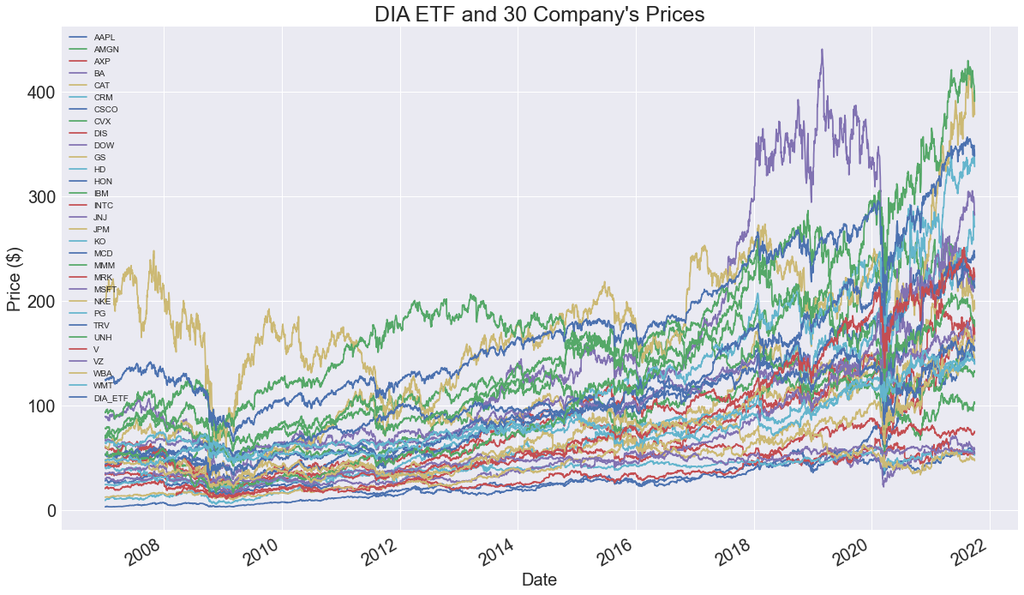

```python
# Plot size and fontsize
df.plot(figsize = (20, 12), fontsize = 20)

# Labels
plt.ylabel('Price ($)', fontsize = 20)
plt.xlabel('Date', fontsize = 20)
plt.title("DIA ETF and 30 Company's Prices", fontsize = 25)

# Show plot
plt.show()
```

### Normalizing Data

From the graph above - we actually can't make much out of it because all stocks are starting out at a different price. In order to make the data more meaningful and determine if a stock performs well or not we need to **normalize** the prices of all stocks to a **common base value** (i.e. $100).

More about normalizing prices [here](https://tcoil.info/normalize-stock-prices-and-time-series-data-with-python-2/) and [here](https://www.linnsoft.com/techind/normalized-price).

We will normalize the prices by doing the following:

1. Divide each and every row by the first row (where we have the starting data and thus, starting prices for stocks in our given timestamp). We should get 1 for the very first row after we've done this.
2. Multiply prices by 100 (common initial base value).

So now, all our stock prices start at $100 and depending on the individual performance, the stocks (and the DIA ETF), end at their respective values - which is now easier to compare.

Our normalized data frame, assigned to "normalized" is shown below:

```python
# divide every row by the first row
# and multiply by 100
normalized = df.div(df.iloc[0])*100
normalized
```

| Date | AAPL | AMGN | AXP | BA | CAT | CRM | CSCO | CVX | DIS | DOW | ... | MSFT | NKE | PG | TRV | UNH | V | VZ | WBA | WMT | DIA_ETF |
| --- | --- | --- | --- | --- | --- | --- | --- | --- | --- | --- | --- | --- | --- | --- | --- | --- | --- | --- | --- | --- | --- |
| 2007-01-03 | 100.000000 | 100.000000 | 100.000000 | 100.000000 | 100.000000 | 100.000000 | 100.000000 | 100.000000 | 100.000000 | NaN | ... | 100.000000 | 100.000000 | 100.000000 | 100.000000 | 100.000000 | NaN | 100.000000 | 100.000000 | 100.000000 | 100.000000 |
| 2007-01-04 | 102.219589 | 104.283626 | 99.271036 | 100.403724 | 99.738391 | 105.018024 | 102.632526 | 99.027755 | 100.789470 | NaN | ... | 99.832548 | 101.023856 | 99.240784 | 99.159662 | 100.646757 | NaN | 100.555262 | 100.195355 | 100.483700 | 100.168715 |
| 2007-01-05 | 101.491649 | 104.532161 | 97.962227 | 99.977575 | 98.463050 | 109.564737 | 102.668589 | 99.408203 | 99.970761 | NaN | ... | 99.263224 | 101.187677 | 98.388595 | 97.871150 | 99.961955 | NaN | 98.836588 | 98.762753 | 99.663512 | 99.413511 |
| 2007-01-08 | 101.992846 | 103.698829 | 98.889990 | 99.742071 | 98.577503 | 110.701416 | 103.245581 | 100.676336 | 100.877187 | NaN | ... | 100.234426 | 100.880517 | 98.605514 | 97.142859 | 101.426669 | NaN | 97.329454 | 99.175166 | 98.843324 | 99.734874 |
| 2007-01-09 | 110.465387 | 104.195899 | 98.260439 | 98.687902 | 99.117068 | 110.784584 | 102.668589 | 99.520919 | 100.730991 | NaN | ... | 100.334891 | 102.139863 | 98.357606 | 96.900094 | 100.209246 | NaN | 97.726064 | 99.696116 | 99.663512 | 99.678636 |
| ... | ... | ... | ... | ... | ... | ... | ... | ... | ... | ... | ... | ... | ... | ... | ... | ... | ... | ... | ... | ... | ... |
| 2021-09-24 | 4909.021687 | 312.295316 | 291.119946 | 248.278573 | 321.811654 | 3167.507705 | 204.579879 | 141.750031 | 521.662319 | NaN | ... | 1002.511721 | 1225.268755 | 222.420206 | 292.175554 | 774.357978 | NaN | 153.993291 | 104.862170 | 301.093587 | 279.480993 |
| 2021-09-27 | 4857.231606 | 311.564321 | 292.859514 | 251.385004 | 327.011119 | 3101.524758 | 202.740722 | 145.089474 | 528.360922 | NaN | ... | 985.164124 | 1212.572917 | 219.491791 | 291.858068 | 770.914954 | NaN | 154.276530 | 105.925764 | 299.158785 | 280.075506 |
| 2021-09-28 | 4741.623293 | 310.336257 | 286.845589 | 244.936647 | 327.910405 | 3019.462169 | 200.216377 | 145.639001 | 517.275626 | NaN | ... | 949.497600 | 1190.130077 | 217.833893 | 286.629333 | 758.265165 | NaN | 153.398506 | 104.384633 | 295.478448 | 275.504146 |
| 2021-09-29 | 4772.363090 | 314.181271 | 284.194817 | 252.730745 | 323.528443 | 2999.722787 | 200.072126 | 145.596731 | 511.821849 | NaN | ... | 951.105138 | 1196.027497 | 220.049585 | 289.225037 | 761.670165 | NaN | 154.021621 | 105.730409 | 295.352271 | 276.187021 |
| 2021-09-30 | 4727.923886 | 310.891797 | 277.551354 | 246.652469 | 313.881625 | 3007.707275 | 196.285616 | 142.947718 | 501.418259 | NaN | ... | 944.139342 | 1189.556658 | 216.609856 | 283.865540 | 743.275618 | NaN | 152.973654 | 102.127197 | 293.123043 | 271.784370 |

3713 rows × 31 columns

Now let's plot our graph again and see what it look like now:

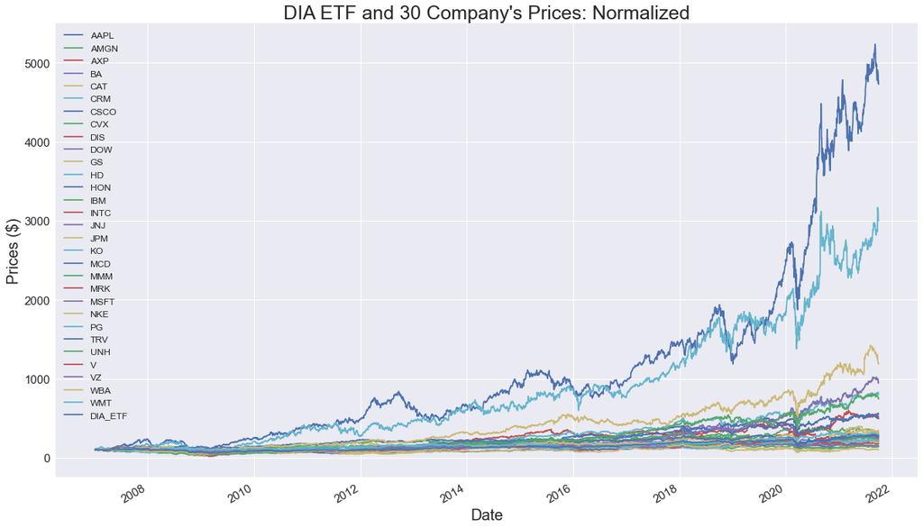

```python
# Plotting graph
normalized.plot(figsize = (20, 12), fontsize = 15)

# Labeling
plt.ylabel('Prices ($)', fontsize = 20)
plt.xlabel('Date', fontsize = 20)
plt.title("DIA ETF and 30 Company's Prices: Normalized",
          fontsize = 25)

# Legend fontsize
plt.legend(fontsize = 12)
plt.labels = True

# Show plot
plt.show()
```

We see that Apple dominates everyone else including the DIA ETF, and Salesforce (CRM) coming in second.

Let's see what the graph looks like when we drop these two companies (Appl, CRM),

and what a graph with just Apple vs DIA looks like:

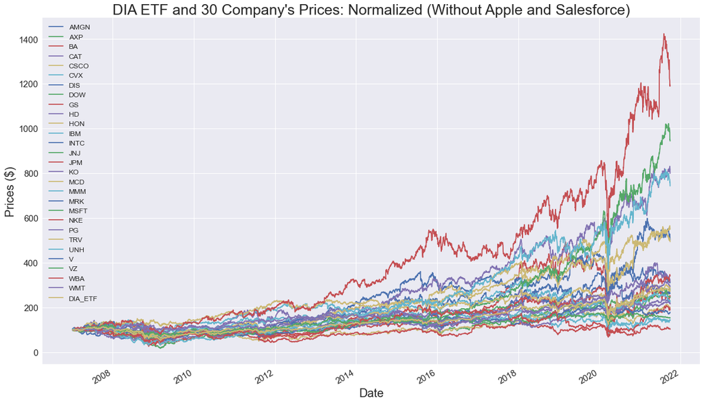

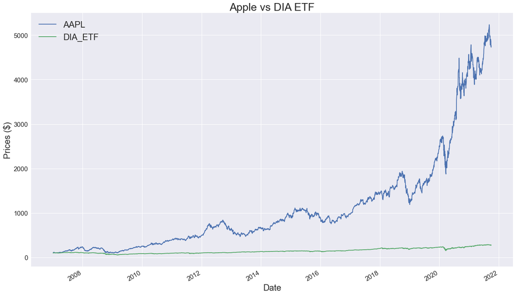

```python
# Drop AAPL and CRM and then plot the graph
normalized.drop(columns = ['AAPL','CRM']).plot(figsize = (20,12), fontsize = 15)

# Labeling and adjusting font
plt.legend(fontsize = 12)
plt.ylabel('Prices ($)', fontsize = 20)
plt.xlabel('Date', fontsize = 20)
plt.title("DIA ETF and 30 Company's Prices: Normalized (Without Apple and Salesforce)",
          fontsize = 25)

# Show plot
plt.show()

print('\n')

# Show just AAPL and DIA and plot graph
plot2 = normalized[['AAPL','DIA_ETF']].plot(figsize = (20,12), fontsize = 15,
                                                       ylabel = 'Prices ($)')

# Labeling and adjusting font
plt.legend(fontsize = 20)
plt.ylabel('Prices ($)', fontsize = 20)
plt.xlabel('Date', fontsize = 20)
plt.title("Apple vs DIA ETF", fontsize = 25)

# Show plot
plt.show()
```

If we want to compare any of the 30 companies **in DIA** with each other, and with the DIA ETF - I've created a function called "compare_companies_with_DIA" that takes as many companies as you want to comapre (as long as they're in DIA) with each other.

For example, let's say I want to just compare Apple and Microsoft with the DIA ETF, I would input their tickers as such:

```
compare_companies_with_DIA('AAPL','MSFT')
```

Note that capitalization of the tickers matter here!

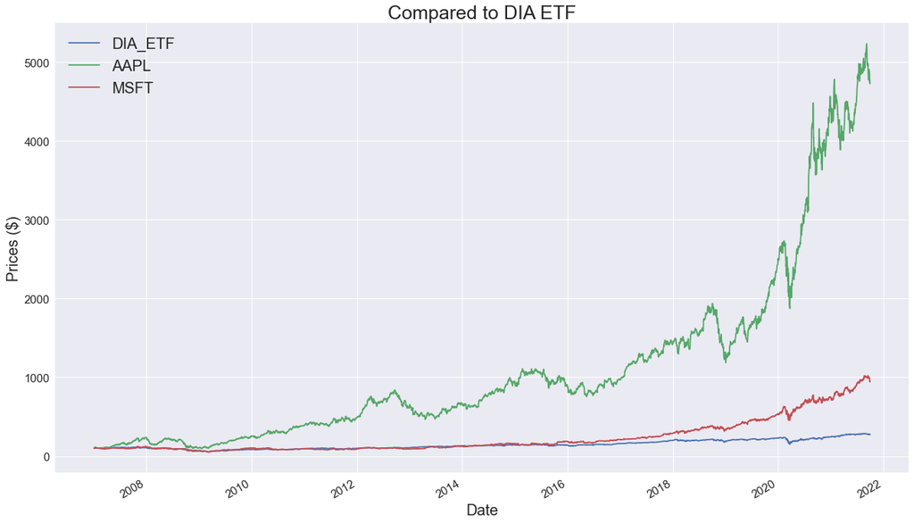

```python
def compare_companies_with_DIA(*args):
    plot = normalized[['DIA_ETF', *args]].plot(figsize = (20,12),
                                               fontsize = 15)

    plt.ylabel('Prices ($)', fontsize = 20)
    plt.xlabel('Date', fontsize = 20)
    plt.title('Compared to DIA ETF', fontsize = 25)
    plt.legend(fontsize = 20)
    plt.show()

compare_companies_with_DIA('AAPL','MSFT')
```

### Annual Return and Annual Volatility

The above charts all still use the **absolute prices** of the stock which does not say much own it's own. In order to better see how an investment's return compares to other similar investments, we want to use **daily returns**.

We can calculate daily returns (percent change in prices) using the formula:

$$\Large \%_{change} = \frac{P_{f}-P_{i}}{P_{i}} * 100 $$

Where $P_{f}$ is the final price and $P_{i}$ is the initial price.

The percentage change in daily prices can be calculated simply by using the [.pct_change( )](https://pandas.pydata.org/docs/reference/api/pandas.DataFrame.pct_change.html) method which computes the percentage change from the immediately previous row by default. We'll add the new data frame with the daily returns to "daily_returns".

Note: even we already used pct_change( ) to calculate the change, python has not yet multiplied by 100 so we would have to do that manually in our code.

```python
daily_returns = df.pct_change()*100 # manually multiplying by 100

daily_returns
```

| Date | AAPL | AMGN | AXP | BA | CAT | CRM | CSCO | CVX | DIS | DOW | ... | MSFT | NKE | PG | TRV | UNH | V | VZ | WBA | WMT | DIA_ETF |
| --- | --- | --- | --- | --- | --- | --- | --- | --- | --- | --- | --- | --- | --- | --- | --- | --- | --- | --- | --- | --- | --- |
| 2007-01-03 | NaN | NaN | NaN | NaN | NaN | NaN | NaN | NaN | NaN | NaN | ... | NaN | NaN | NaN | NaN | NaN | NaN | NaN | NaN | NaN | NaN |
| 2007-01-04 | 2.219589 | 4.283626 | -0.728964 | 0.403724 | -0.261609 | 5.018024 | 2.632526 | -0.972245 | 0.789470 | NaN | ... | -0.167452 | 1.023856 | -0.759216 | -0.840338 | 0.646757 | NaN | 0.555262 | 0.195355 | 0.483700 | 0.168715 |
| 2007-01-05 | -0.712134 | 0.238326 | -1.318420 | -0.424436 | -1.278687 | 4.329460 | 0.035138 | 0.384184 | -0.812296 | NaN | ... | -0.570279 | 0.162160 | -0.858709 | -1.299432 | -0.680402 | NaN | -1.709184 | -1.429809 | -0.816240 | -0.753932 |
| 2007-01-08 | 0.493831 | -0.797202 | 0.947062 | -0.235557 | 0.116240 | 1.037449 | 0.561995 | 1.275682 | 0.906691 | NaN | ... | 0.978411 | -0.303555 | 0.220471 | -0.744132 | 1.465272 | NaN | -1.524875 | 0.417579 | -0.822957 | 0.323260 |
| 2007-01-09 | 8.306995 | 0.479341 | -0.636618 | -1.056895 | 0.547351 | 0.075128 | -0.558854 | -1.147655 | -0.144925 | NaN | ... | 0.100230 | 1.248354 | -0.251414 | -0.249906 | -1.200299 | NaN | 0.407492 | 0.525283 | 0.829786 | -0.056388 |
| ... | ... | ... | ... | ... | ... | ... | ... | ... | ... | ... | ... | ... | ... | ... | ... | ... | ... | ... | ... | ... | ... |
| 2021-09-24 | 0.061293 | -0.669613 | 1.361329 | 0.131159 | 0.101725 | 2.796379 | 0.070561 | 0.539677 | -0.141844 | -1.079573 | ... | -0.070100 | -6.260186 | -0.443858 | 0.282017 | -0.232829 | 1.436643 | -0.091877 | -0.309529 | 0.280167 | 0.089193 |
| 2021-09-27 | -1.054998 | -0.234071 | 0.597543 | 1.251188 | 1.615686 | -2.083119 | -0.898992 | 2.355868 | 1.284088 | 5.069525 | ... | -1.730413 | -1.036168 | -1.316614 | -0.108663 | -0.444629 | -0.859273 | 0.183929 | 1.014278 | -0.642591 | 0.212720 |
| 2021-09-28 | -2.380128 | -0.394161 | -2.053519 | -2.565132 | 0.275002 | -2.645879 | -1.245110 | 0.378750 | -2.098054 | -0.385323 | ... | -3.620364 | -1.850845 | -0.755335 | -1.791534 | -1.640880 | -1.759586 | -0.569123 | -1.454916 | -1.230228 | -1.632188 |
| 2021-09-29 | 0.648297 | 1.238983 | -0.924111 | 3.182087 | -1.336329 | -0.653738 | -0.072048 | -0.029024 | -1.054327 | -1.076353 | ... | 0.169304 | 0.495527 | 1.017148 | 0.905596 | 0.449051 | 0.496540 | 0.406206 | 1.289247 | -0.042703 | 0.247864 |
| 2021-09-30 | -0.931178 | -1.046999 | -2.337644 | -2.405040 | -2.981753 | 0.266174 | -1.892573 | -1.819418 | -2.032658 | -2.142126 | ... | -0.732390 | -0.541028 | -1.563161 | -1.853054 | -2.415028 | -1.733718 | -0.680402 | -3.407924 | -0.754769 | -1.594083 |

3713 rows × 31 columns

Now that we have our daily percent changes, we will find the annual returns and annual volatility using the [.agg( ) method](https://pandas.pydata.org/pandas-docs/stable/reference/api/pandas.DataFrame.agg.html) and adding the data into a new data frame called "return_and_volatility":

For annual returns we get the **mean**, and then multiply it by 252. The **annual** return can be calculated by using the equation:

$$\large \frac{\sum_{i=1}^{n} x_{i}}{n} * 252$$

Where:

- $x_{i}$ is each day
- $n$ is the total number of days
- $252$ is the estimated number of trading days in a year

For annual volatility, we sum up the daily percent change and get the **standard deviation**, and then multiply it by **the square root** of 252. The **annual** volatility (standard deviation) can be calculated by using the equation:

$$\Large \sigma_{annual} = \sqrt{\frac{\sum_{i=1}^{n} (x_{i} - \mu)^2}{n}} * \sqrt{252}$$

Where:

- $\sigma$ is the standard deviation/ volatility
- $n$ is the size of the population (number of days in total)
- $x_{i}$ is each value from the population (each daily return)
- $\mu$ is the population mean (annual return)
- $252$ is the number of estimated trading days in a year

> *"Volatility represents how large an asset's prices swing around the mean price—it is a statistical measure of its dispersion of returns."* - [Investopedia](https://www.investopedia.com/terms/v/volatility.asp)

Useful Information Regarding Volatility:

- [How to Calculate Annualized Volatility](https://www.fool.com/knowledge-center/how-to-calculate-annualized-volatility.aspx)
- [Why Is Volatility Proportional to the Square Root of Time?](https://www.macroption.com/why-is-volatility-proportional-to-square-root-of-time/)

Volatility is also a measure of [active risk](https://www.investopedia.com/terms/a/activerisk.asp).

```python
# Annualize by multiplying with 252 (estimated # of trading
# days in a year)
return_and_volatility = daily_returns.agg(['mean','std']).T
# .T is same as saying .transpose()

return_and_volatility.rename(columns = {'mean':'Annual_Return',
                                  'std':'Annual_Volatility'}, inplace = True)

return_and_volatility.rename(columns = {'mean':'Annual_Return'}, inplace = True)

return_and_volatility['Annual_Return'] = return_and_volatility['Annual_Return'] * 252

return_and_volatility['Annual_Volatility'] = (return_and_volatility['Annual_Volatility'] *
                                              np.sqrt(252))


return_and_volatility
```

|  | Annual_Return | Annual_Volatility |
| --- | --- | --- |
| AAPL | 31.401284 | 32.238952 |
| AMGN | 11.313817 | 26.952520 |
| AXP | 14.194831 | 38.280729 |
| BA | 12.621012 | 36.037748 |
| CAT | 13.113739 | 32.700060 |
| CRM | 31.355649 | 40.790727 |
| CSCO | 8.890924 | 29.322477 |
| CVX | 6.902080 | 29.893946 |
| DIS | 14.911727 | 28.240365 |
| DOW | 16.523834 | 46.206825 |
| GS | 11.434469 | 37.940882 |
| HD | 17.770499 | 27.024896 |
| HON | 14.428979 | 26.788914 |
| IBM | 5.279904 | 23.883548 |
| INTC | 11.460878 | 31.347639 |
| JNJ | 7.616250 | 17.792703 |
| JPM | 16.379127 | 40.366002 |
| KO | 7.104053 | 19.370313 |
| MCD | 13.691260 | 20.613517 |
| MMM | 8.229703 | 23.412935 |
| MRK | 7.072138 | 24.989306 |
| MSFT | 19.200636 | 28.165492 |
| NKE | 20.931522 | 28.786933 |
| PG | 7.009458 | 18.779946 |
| TRV | 11.306707 | 29.046405 |
| UNH | 18.954264 | 32.820777 |
| V | 24.905804 | 30.053151 |
| VZ | 5.118789 | 21.168454 |
| WBA | 4.397929 | 29.140969 |
| WMT | 9.400557 | 20.525982 |
| DIA_ETF | 8.737816 | 19.746164 |

It can be hard to see what comapny we're looking at form tickers alone - so let's also add the company names into our "return_and_volatility" data frame:

```python
# Merging data frames by common column "Ticker"
return_and_volatility = return_and_volatility.merge(
    dow_companies.loc[: , ["Ticker","Company"]],
    how = 'left', left_index = True, right_on = 'Ticker')

# Setting index column
return_and_volatility.set_index("Company", inplace = True)

# DIA Closing Price is not part of the 30 companies when
# we merged the dow_companies data frame so it resulted
# in a 'NaN' company name - we just simply rename it here:
return_and_volatility.rename(index = {np.nan : "DIA ETF"}, inplace = True)

return_and_volatility
```

| Company | Annual_Return | Annual_Volatility | Ticker |
| --- | --- | --- | --- |
| Apple Inc. | 31.401284 | 32.238952 | AAPL |
| Amgen | 11.313817 | 26.952520 | AMGN |
| American Express | 14.194831 | 38.280729 | AXP |
| Boeing | 12.621012 | 36.037748 | BA |
| Caterpillar Inc. | 13.113739 | 32.700060 | CAT |
| Salesforce | 31.355649 | 40.790727 | CRM |
| Cisco Systems | 8.890924 | 29.322477 | CSCO |
| Chevron Corporation | 6.902080 | 29.893946 | CVX |
| The Walt Disney Company | 14.911727 | 28.240365 | DIS |
| Dow Inc. | 16.523834 | 46.206825 | DOW |
| Goldman Sachs | 11.434469 | 37.940882 | GS |
| The Home Depot | 17.770499 | 27.024896 | HD |
| Honeywell | 14.428979 | 26.788914 | HON |
| IBM | 5.279904 | 23.883548 | IBM |
| Intel | 11.460878 | 31.347639 | INTC |
| Johnson & Johnson | 7.616250 | 17.792703 | JNJ |
| JPMorgan Chase | 16.379127 | 40.366002 | JPM |
| The Coca-Cola Company | 7.104053 | 19.370313 | KO |
| McDonald's | 13.691260 | 20.613517 | MCD |
| 3M | 8.229703 | 23.412935 | MMM |
| Merck & Co. | 7.072138 | 24.989306 | MRK |
| Microsoft | 19.200636 | 28.165492 | MSFT |
| Nike, Inc. | 20.931522 | 28.786933 | NKE |
| Procter & Gamble | 7.009458 | 18.779946 | PG |
| The Travelers Companies | 11.306707 | 29.046405 | TRV |
| UnitedHealth Group | 18.954264 | 32.820777 | UNH |
| Visa Inc. | 24.905804 | 30.053151 | V |
| Verizon Communications | 5.118789 | 21.168454 | VZ |
| Walgreens Boots Alliance | 4.397929 | 29.140969 | WBA |
| Walmart | 9.400557 | 20.525982 | WMT |
| DIA ETF | 8.737816 | 19.746164 | DIA_ETF |

## Exploratory Data Analysis

In this section we are going to compare the historical performance of our stocks, meaning we'll look closer into returns and volatility. Typically [high returns go hand-in-hand with higher volatility](https://www.investopedia.com/ask/answers/010915/volatility-good-thing-or-bad-thing-investors-point-view-and-why.asp), but this can also lead to more significant losses.

> *"The good news is that as volatility increases, the potential to make more money quickly also increases. The bad news is that higher volatility also means higher risk."* - Charles Schwab

Before we start we're actually going to drop Dow Inc. (ticker: DOW) because it only contains 639 data points versus the 3,000+ for other companies (even V has the data for 3,408 timestamps here).

See row #9.

We will assign the new data frame to "return_and_volatility2" shown below:

```python
# Showing summary
# daily_returns.info()

# Dropping DOW
return_and_volatility2 = return_and_volatility.drop(index = 'Dow Inc.')

display(return_and_volatility2)
```

| Company | Annual_Return | Annual_Volatility | Ticker |
| --- | --- | --- | --- |
| Apple Inc. | 31.401284 | 32.238952 | AAPL |
| Amgen | 11.313817 | 26.952520 | AMGN |
| American Express | 14.194831 | 38.280729 | AXP |
| Boeing | 12.621012 | 36.037748 | BA |
| Caterpillar Inc. | 13.113739 | 32.700060 | CAT |
| Salesforce | 31.355649 | 40.790727 | CRM |
| Cisco Systems | 8.890924 | 29.322477 | CSCO |
| Chevron Corporation | 6.902080 | 29.893946 | CVX |
| The Walt Disney Company | 14.911727 | 28.240365 | DIS |
| Goldman Sachs | 11.434469 | 37.940882 | GS |
| The Home Depot | 17.770499 | 27.024896 | HD |
| Honeywell | 14.428979 | 26.788914 | HON |
| IBM | 5.279904 | 23.883548 | IBM |
| Intel | 11.460878 | 31.347639 | INTC |
| Johnson & Johnson | 7.616250 | 17.792703 | JNJ |
| JPMorgan Chase | 16.379127 | 40.366002 | JPM |
| The Coca-Cola Company | 7.104053 | 19.370313 | KO |
| McDonald's | 13.691260 | 20.613517 | MCD |
| 3M | 8.229703 | 23.412935 | MMM |
| Merck & Co. | 7.072138 | 24.989306 | MRK |
| Microsoft | 19.200636 | 28.165492 | MSFT |
| Nike, Inc. | 20.931522 | 28.786933 | NKE |
| Procter & Gamble | 7.009458 | 18.779946 | PG |
| The Travelers Companies | 11.306707 | 29.046405 | TRV |
| UnitedHealth Group | 18.954264 | 32.820777 | UNH |
| Visa Inc. | 24.905804 | 30.053151 | V |
| Verizon Communications | 5.118789 | 21.168454 | VZ |
| Walgreens Boots Alliance | 4.397929 | 29.140969 | WBA |
| Walmart | 9.400557 | 20.525982 | WMT |
| DIA ETF | 8.737816 | 19.746164 | DIA_ETF |

Now let's visualize our annual returns and volatility in two plots of descending order: first by return and then by volatility.

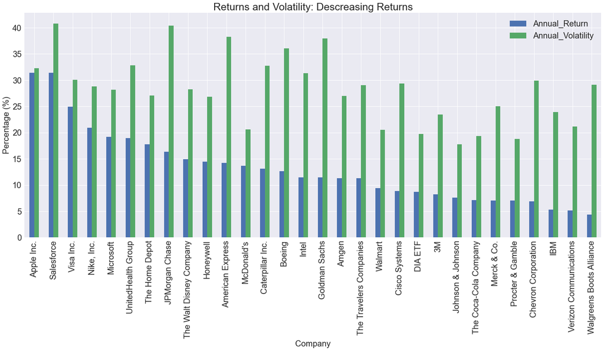

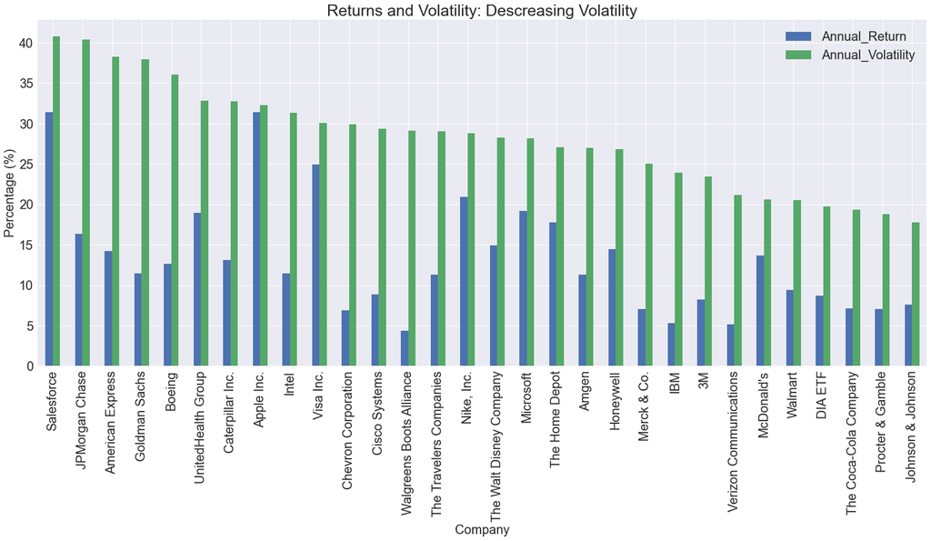

```python
# Sorting and plotting
return_and_volatility2.sort_values(
        by = 'Annual_Return', ascending = False).plot(kind = 'bar',
                                                      figsize = (25,10),
                                                      fontsize = 20)
# Labeling and adjusting fontsize
plt.title('Returns and Volatility: Descreasing Returns', fontsize = 25)
plt.ylabel('Percentage (%)', fontsize = 20)
plt.xlabel('Company', fontsize = 20)
plt.legend(fontsize = 20)

# Show plot
plt.show()

print('\n')
print('\n')

return_and_volatility2.sort_values(
        by = "Annual_Volatility", ascending = False).plot(kind = 'bar',
                                                          figsize = (25,10),
                                                          fontsize = 20)

# Labeling and adjusting fontsize
plt.title('Returns and Volatility: Descreasing Volatility', fontsize = 25)
plt.ylabel('Percentage (%)', fontsize = 20)
plt.xlabel('Company', fontsize = 20)
plt.legend(fontsize = 20)

# Show plot
plt.show()
```

Let's see the two metrics on a scatter plot. The goal is to better visualize companies that have high returns and decent volatility. For returns, keep in mind we did **not focus on dividends** here!

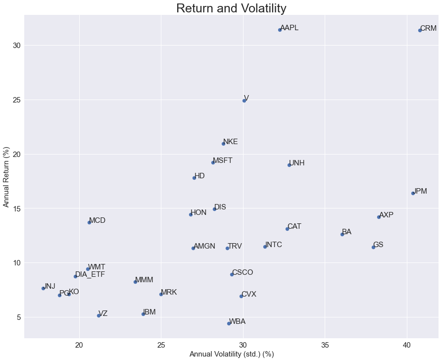

```python
# Setting index to 'Ticker' because our scatterplot will look messy if the
# full company name is shown instead (previous index was 'Company')
return_and_volatility2.set_index('Ticker', inplace = True)

# Creating scatterplot
return_and_volatility2.plot(kind = 'scatter',
                            x = 'Annual_Volatility',
                            y = 'Annual_Return',
                            figsize = (15,12),
                            s = 50,
                            fontsize = 15)

# Labeling each point on the scatter plot with their respective ticker
for i in return_and_volatility2.index:
    plt.annotate(i, xy=(return_and_volatility2.loc[i, 'Annual_Volatility'],
                        return_and_volatility2.loc[i, 'Annual_Return']), size = 15)

# Labeling
plt.xlabel('Annual Volatility (std.) (%)', fontsize = 15)
plt.ylabel('Annual Return (%)', fontsize = 15)
plt.title('Return and Volatility', fontsize = 25)

# Show plot
plt.show()
```

Just for fun, let's see how these stocks correlate to **one another**. First, we'll create a correlation matrix using the [.corr( ) method](https://pandas.pydata.org/docs/reference/api/pandas.DataFrame.corr.html). Then, we can use the seaborn library [heatmap](https://seaborn.pydata.org/generated/seaborn.heatmap.html) to generate a heatmap because simply looking at the correlation numbers in a data frame is not very visually appealing nor efficient.

|  | AAPL | AMGN | AXP | BA | CAT | CRM | CSCO | CVX | DIS | DOW | ... | MSFT | NKE | PG | TRV | UNH | V | VZ | WBA | WMT | DIA_ETF |
| --- | --- | --- | --- | --- | --- | --- | --- | --- | --- | --- | --- | --- | --- | --- | --- | --- | --- | --- | --- | --- | --- |
| AAPL | 1.000000 | 0.363291 | 0.445503 | 0.399638 | 0.451448 | 0.462752 | 0.514660 | 0.413129 | 0.435611 | 0.422990 | ... | 0.547570 | 0.425639 | 0.359788 | 0.404820 | 0.385759 | 0.495361 | 0.340768 | 0.328526 | 0.323061 | 0.605704 |
| AMGN | 0.363291 | 1.000000 | 0.365203 | 0.327756 | 0.365247 | 0.341509 | 0.409041 | 0.414364 | 0.407635 | 0.386286 | ... | 0.460050 | 0.350968 | 0.452365 | 0.401338 | 0.423399 | 0.391161 | 0.369965 | 0.374948 | 0.365698 | 0.560590 |
| AXP | 0.445503 | 0.365203 | 1.000000 | 0.564142 | 0.601088 | 0.429520 | 0.538285 | 0.587275 | 0.628525 | 0.643003 | ... | 0.514680 | 0.513704 | 0.433649 | 0.614873 | 0.453351 | 0.610442 | 0.454856 | 0.407035 | 0.335006 | 0.753031 |
| BA | 0.399638 | 0.327756 | 0.564142 | 1.000000 | 0.539510 | 0.374158 | 0.452881 | 0.571981 | 0.552418 | 0.550624 | ... | 0.448883 | 0.463296 | 0.370775 | 0.475773 | 0.399249 | 0.460202 | 0.353668 | 0.389053 | 0.285903 | 0.713383 |
| CAT | 0.451448 | 0.365247 | 0.601088 | 0.539510 | 1.000000 | 0.449200 | 0.554990 | 0.618561 | 0.574196 | 0.754861 | ... | 0.505444 | 0.477944 | 0.395884 | 0.488290 | 0.392720 | 0.497819 | 0.435613 | 0.410640 | 0.336682 | 0.748250 |
| CRM | 0.462752 | 0.341509 | 0.429520 | 0.374158 | 0.449200 | 1.000000 | 0.498557 | 0.394417 | 0.443413 | 0.361669 | ... | 0.526927 | 0.436194 | 0.324032 | 0.373071 | 0.327178 | 0.481468 | 0.347219 | 0.303147 | 0.288038 | 0.564005 |
| CSCO | 0.514660 | 0.409041 | 0.538285 | 0.452881 | 0.554990 | 0.498557 | 1.000000 | 0.521359 | 0.561405 | 0.522880 | ... | 0.610533 | 0.485272 | 0.470486 | 0.475885 | 0.404126 | 0.514422 | 0.457727 | 0.420199 | 0.403468 | 0.716440 |
| CVX | 0.413129 | 0.414364 | 0.587275 | 0.571981 | 0.618561 | 0.394417 | 0.521359 | 1.000000 | 0.586169 | 0.614519 | ... | 0.508716 | 0.448748 | 0.456850 | 0.572286 | 0.477612 | 0.509578 | 0.468611 | 0.403187 | 0.333258 | 0.774196 |
| DIS | 0.435611 | 0.407635 | 0.628525 | 0.552418 | 0.574196 | 0.443413 | 0.561405 | 0.586169 | 1.000000 | 0.520173 | ... | 0.532838 | 0.526477 | 0.491364 | 0.536801 | 0.450069 | 0.534440 | 0.470130 | 0.425818 | 0.385311 | 0.758711 |
| DOW | 0.422990 | 0.386286 | 0.643003 | 0.550624 | 0.754861 | 0.361669 | 0.522880 | 0.614519 | 0.520173 | 1.000000 | ... | 0.431995 | 0.489226 | 0.378056 | 0.615861 | 0.414693 | 0.573613 | 0.454681 | 0.461064 | 0.333342 | 0.722702 |
| GS | 0.456062 | 0.345634 | 0.683967 | 0.500220 | 0.573572 | 0.435451 | 0.534918 | 0.562066 | 0.575181 | 0.672508 | ... | 0.499755 | 0.458742 | 0.386974 | 0.577540 | 0.450709 | 0.546569 | 0.418373 | 0.396123 | 0.327707 | 0.718886 |
| HD | 0.461984 | 0.408415 | 0.574569 | 0.481628 | 0.511272 | 0.450221 | 0.529726 | 0.504165 | 0.565424 | 0.500555 | ... | 0.533556 | 0.547631 | 0.480347 | 0.541818 | 0.458591 | 0.531135 | 0.478274 | 0.428289 | 0.479909 | 0.733189 |
| HON | 0.476900 | 0.439899 | 0.646760 | 0.656186 | 0.704782 | 0.466680 | 0.593272 | 0.655554 | 0.664516 | 0.646250 | ... | 0.563043 | 0.553889 | 0.483517 | 0.568439 | 0.487119 | 0.567420 | 0.484749 | 0.467161 | 0.383133 | 0.821372 |
| IBM | 0.463788 | 0.391098 | 0.516411 | 0.497382 | 0.542806 | 0.433409 | 0.578903 | 0.546065 | 0.532070 | 0.617454 | ... | 0.535082 | 0.471846 | 0.469958 | 0.507679 | 0.406312 | 0.494098 | 0.464500 | 0.430954 | 0.378659 | 0.730419 |
| INTC | 0.512405 | 0.420958 | 0.520821 | 0.451214 | 0.531168 | 0.460680 | 0.597365 | 0.501950 | 0.503917 | 0.454015 | ... | 0.621382 | 0.441942 | 0.426316 | 0.482981 | 0.394152 | 0.478792 | 0.433031 | 0.388522 | 0.376565 | 0.689169 |
| JNJ | 0.369410 | 0.531987 | 0.444344 | 0.413807 | 0.450955 | 0.345372 | 0.499339 | 0.515508 | 0.483626 | 0.400367 | ... | 0.493320 | 0.425200 | 0.599053 | 0.494958 | 0.491083 | 0.448263 | 0.506664 | 0.440150 | 0.461104 | 0.687822 |
| JPM | 0.427298 | 0.348344 | 0.732920 | 0.493064 | 0.557976 | 0.401969 | 0.520270 | 0.541058 | 0.576683 | 0.699889 | ... | 0.472273 | 0.482328 | 0.410381 | 0.622555 | 0.413356 | 0.548290 | 0.453292 | 0.406614 | 0.334617 | 0.723355 |
| KO | 0.352515 | 0.387877 | 0.463406 | 0.456305 | 0.435951 | 0.331435 | 0.443128 | 0.507408 | 0.511687 | 0.533776 | ... | 0.471428 | 0.430526 | 0.586701 | 0.502065 | 0.436203 | 0.402391 | 0.497660 | 0.386849 | 0.405671 | 0.659232 |
| MCD | 0.391858 | 0.384915 | 0.480620 | 0.467214 | 0.415826 | 0.379919 | 0.448292 | 0.505939 | 0.495523 | 0.475407 | ... | 0.477558 | 0.489425 | 0.475411 | 0.502804 | 0.413604 | 0.477773 | 0.413198 | 0.340428 | 0.393696 | 0.665674 |
| MMM | 0.449261 | 0.441641 | 0.578246 | 0.512916 | 0.647424 | 0.416928 | 0.580197 | 0.578282 | 0.582707 | 0.583323 | ... | 0.524095 | 0.498778 | 0.504548 | 0.547278 | 0.447220 | 0.496443 | 0.485744 | 0.453613 | 0.398523 | 0.771842 |
| MRK | 0.337833 | 0.476293 | 0.425591 | 0.348330 | 0.389117 | 0.342292 | 0.434315 | 0.468380 | 0.445688 | 0.380527 | ... | 0.426877 | 0.377179 | 0.488506 | 0.465954 | 0.444207 | 0.398815 | 0.471530 | 0.367250 | 0.376416 | 0.612344 |
| MSFT | 0.547570 | 0.460050 | 0.514680 | 0.448883 | 0.505444 | 0.526927 | 0.610533 | 0.508716 | 0.532838 | 0.431995 | ... | 1.000000 | 0.472224 | 0.473044 | 0.485156 | 0.440805 | 0.518930 | 0.447716 | 0.385514 | 0.400024 | 0.715348 |
| NKE | 0.425639 | 0.350968 | 0.513704 | 0.463296 | 0.477944 | 0.436194 | 0.485272 | 0.448748 | 0.526477 | 0.489226 | ... | 0.472224 | 1.000000 | 0.424805 | 0.448998 | 0.394655 | 0.482911 | 0.413890 | 0.368328 | 0.377756 | 0.652497 |
| PG | 0.359788 | 0.452365 | 0.433649 | 0.370775 | 0.395884 | 0.324032 | 0.470486 | 0.456850 | 0.491364 | 0.378056 | ... | 0.473044 | 0.424805 | 1.000000 | 0.475906 | 0.402570 | 0.408060 | 0.525952 | 0.414054 | 0.499353 | 0.653368 |
| TRV | 0.404820 | 0.401338 | 0.614873 | 0.475773 | 0.488290 | 0.373071 | 0.475885 | 0.572286 | 0.536801 | 0.615861 | ... | 0.485156 | 0.448998 | 0.475906 | 1.000000 | 0.482491 | 0.503487 | 0.478847 | 0.381839 | 0.405165 | 0.707387 |
| UNH | 0.385759 | 0.423399 | 0.453351 | 0.399249 | 0.392720 | 0.327178 | 0.404126 | 0.477612 | 0.450069 | 0.414693 | ... | 0.440805 | 0.394655 | 0.402570 | 0.482491 | 1.000000 | 0.408425 | 0.351991 | 0.357716 | 0.337002 | 0.610862 |
| V | 0.495361 | 0.391161 | 0.610442 | 0.460202 | 0.497819 | 0.481468 | 0.514422 | 0.509578 | 0.534440 | 0.573613 | ... | 0.518930 | 0.482911 | 0.408060 | 0.503487 | 0.408425 | 1.000000 | 0.387444 | 0.352685 | 0.353556 | 0.675345 |
| VZ | 0.340768 | 0.369965 | 0.454856 | 0.353668 | 0.435613 | 0.347219 | 0.457727 | 0.468611 | 0.470130 | 0.454681 | ... | 0.447716 | 0.413890 | 0.525952 | 0.478847 | 0.351991 | 0.387444 | 1.000000 | 0.368698 | 0.434558 | 0.626219 |
| WBA | 0.328526 | 0.374948 | 0.407035 | 0.389053 | 0.410640 | 0.303147 | 0.420199 | 0.403187 | 0.425818 | 0.461064 | ... | 0.385514 | 0.368328 | 0.414054 | 0.381839 | 0.357716 | 0.352685 | 0.368698 | 1.000000 | 0.388807 | 0.557280 |
| WMT | 0.323061 | 0.365698 | 0.335006 | 0.285903 | 0.336682 | 0.288038 | 0.403468 | 0.333258 | 0.385311 | 0.333342 | ... | 0.400024 | 0.377756 | 0.499353 | 0.405165 | 0.337002 | 0.353556 | 0.434558 | 0.388807 | 1.000000 | 0.546459 |
| DIA_ETF | 0.605704 | 0.560590 | 0.753031 | 0.713383 | 0.748250 | 0.564005 | 0.716440 | 0.774196 | 0.758711 | 0.722702 | ... | 0.715348 | 0.652497 | 0.653368 | 0.707387 | 0.610862 | 0.675345 | 0.626219 | 0.557280 | 0.546459 | 1.000000 |

31 rows × 31 columns

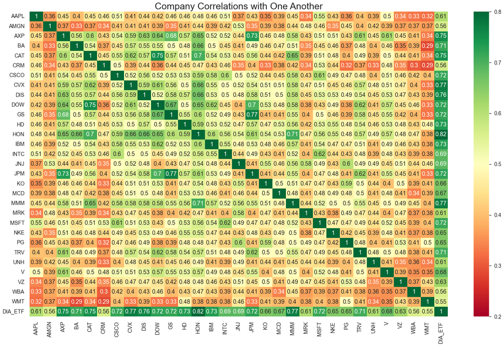

```python
# Creating a correlation matrix using
corr_matrix = daily_returns.corr()

display(corr_matrix)

print('\n')
print('\n')

# Seaborn heatmap
sns.set(font_scale=1.3)
plt.figure(figsize = (25,15))
sns.heatmap(corr_matrix, cmap = 'RdYlGn', annot = True, vmin = 0.2, vmax = 0.8)
plt.title('Company Correlations with One Another', fontsize = 25)

plt.show()
```

## Index Tracking Intro

Before diving into the index tracking portion, we need to understand here that indexes, index funds, and exchange traded funds are **not the same thing**.

- [An Introduction to U.S. Stock Market Indexes](https://www.investopedia.com/insights/introduction-to-stock-market-indices/)
- [Difference Between Indexes and Index Funds](http://www.moneychimp.com/articles/index_funds/overview.htm#:~:text=A%20stock%20index%20is%20a,portfolio%20that%20approximates%20the%20index.)
- [Difference Between Index Funds and ETFs](https://www.investopedia.com/ask/answers/033015/whats-difference-between-index-fund-and-etf.asp)

Although we can invest directly into DIA since it is an ETF, let's say we don't want to pay the [expense ratio](https://www.investopedia.com/terms/e/expenseratio.asp) for whatever reason. The DIA ETF expense ratio as of Nov. 9th, 2021 is [0.16% annually](https://www.ssga.com/us/en/intermediary/etfs/funds/spdr-dow-jones-industrial-average-etf-trust-dia).

Here is an example of the expense ratio according to Investopedia:

> The Vanguard S&P 500 ETF (ticker: VOO), an index fund that replicates the Standard & Poor's (S&P) 500 Index, has one of the lowest expense ratios in the industry at 0.03% annually. At this level, investors are charged just \$3 per year for every $10,000 invested.

So, we're going to track the DIA ETF (which in turn replicates the DJIA Index). **To keep things simple moving forward**, since we are technically tracking the DJIA index anyways **through tracking DIA**, we'll just say we're **tracking the DJIA Index**. Also I'm going to use DIA and DJIA interchangeably, but just know that they both mean the same thing for now.

Remember that you [can't invest in the **DJIA Index**](https://www.investopedia.com/ask/answers/100214/can-you-buy-shares-dow-jones-industrial-average-djia.asp) itself!

### The Plan

We're going to track the DJIA using a subset of only 10 stocks (from DJIA) because we are too broke to afford more than 10 and do not want to pay the DIA ETF expense ratio.

The criteria in choosing which specific 10 stocks to include in our tracking portfolio will be to look at those with the lowest individual [tracking error](https://www.investopedia.com/terms/t/trackingerror.asp) (TE). We will calculate the TE in our training/ fitting period.

- Training Period: 2017 & 2018
- Forward Testing Period: 2019

We're going to fit the parameters of our portfolio to the data in the training period (2 years). This doesn't guarantee that the tracking portfolio does a good job on new data so we will **forward test** our tracking portfolio's ability to track the index and use 2019 as the forward test period.

Lastly, once we have identified the 10 stocks to include in our tracking portfolio, we need to find their optimal weights in the portfolio to minimize TE.

First let's select the closing prices of stocks (including DIA) only within 2017 and 2018 and normailze these prices. We will assign this to a new data frame called, "df2_normalized".

We will also create a new data frame for daily returns, only containing the data from 2017 and 2018 - and assign it to "daily_returns2"

```python
# Recall our data frame "df" that contains
# the closing price data of all companies
# including the DIA ETF prices. We created this
# data frame back in the section:
# "Visualizing DIA Prices vs Each Company's Prices"

# Only selecting the two years: 2017, 2018
# and store in data frame "df2"
df2 = df.loc['2017':'2018'].copy()

# Normalizing df2 (setting base start prices
# of all companies to $100)
# Divide every row by the first row
# and multiply by 100
df2_normalized = df2.div(df2.iloc[0])*100
print('\033[4mNormalized Closing Prices for 2017-2018 Only\033[0m')
display(df2_normalized)

print('\n')
print('\n')

# Recall our returns (percent change) dataframe
# called "daily_returns". We're going to adjust
# it so that it only contains data from the years
# 2017-2018 and assign it to a new variable name:
daily_returns2 = daily_returns['2017':'2018'].copy()
print('\033[4mDaily Returns (percent change) for 2017-2018 Only\033[0m')
display(daily_returns2)
```

```
Normalized Closing Prices for 2017-2018 Only
```

| Date | AAPL | AMGN | AXP | BA | CAT | CRM | CSCO | CVX | DIS | DOW | ... | MSFT | NKE | PG | TRV | UNH | V | VZ | WBA | WMT | DIA_ETF |
| --- | --- | --- | --- | --- | --- | --- | --- | --- | --- | --- | --- | --- | --- | --- | --- | --- | --- | --- | --- | --- | --- |
| 2017-01-03 | 100.000000 | 100.000000 | 100.000000 | 100.000000 | 100.000000 | 100.000000 | 100.000000 | 100.000000 | 100.000000 | NaN | ... | 100.000000 | 100.000000 | 100.000000 | 100.000000 | 100.000000 | 100.000000 | 100.000000 | 100.000000 | 100.000000 | 100.000000 |
| 2017-01-04 | 99.888072 | 101.419757 | 101.207702 | 101.051152 | 99.553146 | 103.203859 | 98.559265 | 99.974545 | 101.282052 | NaN | ... | 99.552569 | 102.096961 | 100.356298 | 99.462364 | 100.284922 | 100.817612 | 99.890067 | 100.024113 | 100.582572 | 100.367904 |
| 2017-01-05 | 100.396039 | 101.492735 | 99.960187 | 101.108496 | 98.946699 | 103.189680 | 98.788471 | 99.541790 | 101.225486 | NaN | ... | 99.552569 | 102.077726 | 101.021378 | 97.874277 | 100.452150 | 101.999995 | 100.109926 | 100.084378 | 100.801042 | 100.166315 |
| 2017-01-06 | 101.515284 | 104.013802 | 100.159260 | 101.356950 | 98.989257 | 104.621494 | 98.984933 | 99.142977 | 102.733787 | NaN | ... | 100.415466 | 103.712967 | 100.985750 | 97.824644 | 100.594616 | 103.408804 | 97.581525 | 100.168755 | 99.417417 | 100.549338 |
| 2017-01-09 | 102.445111 | 105.380482 | 100.676844 | 100.860041 | 98.276418 | 104.848310 | 98.821216 | 98.294440 | 102.149320 | NaN | ... | 100.095873 | 102.693347 | 100.237535 | 97.038874 | 100.309693 | 102.830189 | 96.518869 | 99.505791 | 100.072816 | 100.171352 |
| ... | ... | ... | ... | ... | ... | ... | ... | ... | ... | ... | ... | ... | ... | ... | ... | ... | ... | ... | ... | ... | ... |
| 2018-12-24 | 126.414120 | 118.357327 | 118.779034 | 187.398867 | 124.428130 | 172.001702 | 131.892592 | 85.693678 | 94.598413 | NaN | ... | 150.415459 | 131.011926 | 103.752974 | 93.159633 | 144.279967 | 153.119501 | 97.196771 | 78.664420 | 124.992711 | 109.918359 |
| 2018-12-26 | 135.316398 | 124.633454 | 124.538817 | 199.993623 | 132.737531 | 185.483406 | 139.063523 | 91.124311 | 99.764329 | NaN | ... | 160.690308 | 140.457874 | 106.995249 | 96.914803 | 150.727786 | 163.811315 | 99.743490 | 81.629703 | 131.677831 | 115.265603 |
| 2018-12-27 | 134.438219 | 126.272147 | 125.653619 | 202.038614 | 134.769657 | 191.664297 | 140.504252 | 92.761987 | 100.414776 | NaN | ... | 161.681044 | 141.727585 | 109.287411 | 98.155498 | 152.350577 | 166.050308 | 101.044338 | 82.401159 | 133.396434 | 116.550749 |
| 2018-12-28 | 134.507097 | 126.537518 | 125.308560 | 201.554439 | 133.641880 | 190.927121 | 140.045839 | 92.193469 | 101.150077 | NaN | ... | 160.418658 | 141.092722 | 108.289791 | 97.799832 | 152.517814 | 164.704406 | 101.264197 | 82.027488 | 134.182919 | 116.157644 |
| 2018-12-31 | 135.807149 | 129.151465 | 126.502988 | 205.453270 | 135.195236 | 194.173518 | 141.879504 | 92.312263 | 103.365384 | NaN | ... | 162.304245 | 142.631782 | 109.168648 | 99.048799 | 154.301641 | 165.962267 | 103.004762 | 82.364998 | 135.668506 | 117.528474 |

502 rows × 31 columns

```
Daily Returns (percent change) for 2017-2018 Only
```

| Date | AAPL | AMGN | AXP | BA | CAT | CRM | CSCO | CVX | DIS | DOW | ... | MSFT | NKE | PG | TRV | UNH | V | VZ | WBA | WMT | DIA_ETF |
| --- | --- | --- | --- | --- | --- | --- | --- | --- | --- | --- | --- | --- | --- | --- | --- | --- | --- | --- | --- | --- | --- |
| 2017-01-03 | 0.284926 | 3.091436 | 1.714358 | 0.828628 | 1.347854 | 3.038273 | 1.058907 | 0.127444 | 1.784687 | NaN | ... | 0.708082 | 2.262439 | 0.142715 | -1.241624 | 0.881032 | 1.896954 | 2.248034 | 0.241659 | -0.665508 | 0.460738 |
| 2017-01-04 | -0.111928 | 1.419757 | 1.207702 | 1.051152 | -0.446854 | 3.203859 | -1.440735 | -0.025455 | 1.282052 | NaN | ... | -0.447431 | 2.096961 | 0.356298 | -0.537636 | 0.284922 | 0.817612 | -0.109933 | 0.024113 | 0.582572 | 0.367904 |
| 2017-01-05 | 0.508536 | 0.071957 | -1.232628 | 0.056747 | -0.609169 | -0.013739 | 0.232557 | -0.432866 | -0.055850 | NaN | ... | 0.000000 | -0.018840 | 0.662719 | -1.596672 | 0.166753 | 1.172795 | 0.220101 | 0.060250 | 0.217205 | -0.200851 |
| 2017-01-06 | 1.114830 | 2.483987 | 0.199152 | 0.245731 | 0.043012 | 1.387556 | 0.198871 | -0.400649 | 1.490041 | NaN | ... | 0.866775 | 1.601957 | -0.035268 | -0.050710 | 0.141825 | 1.381185 | -2.525624 | 0.084307 | -1.372630 | 0.382387 |
| 2017-01-09 | 0.915948 | 1.313942 | 0.516761 | -0.490257 | -0.720118 | 0.216797 | -0.165396 | -0.855871 | -0.568914 | NaN | ... | -0.318270 | -0.983118 | -0.740912 | -0.803244 | -0.283238 | -0.559542 | -1.088994 | -0.661848 | 0.659240 | -0.375921 |
| ... | ... | ... | ... | ... | ... | ... | ... | ... | ... | ... | ... | ... | ... | ... | ... | ... | ... | ... | ... | ... | ... |
| 2018-12-24 | -2.587404 | -1.004391 | -2.003725 | -3.411586 | -2.598487 | -1.285495 | -3.751493 | -3.089916 | -3.713301 | NaN | ... | -4.173884 | -5.900241 | -3.968342 | -2.955368 | -2.265668 | -2.036052 | -3.404951 | -2.973535 | -1.503498 | -2.673029 |
| 2018-12-26 | 7.042155 | 5.302695 | 4.849158 | 6.720828 | 6.678072 | 7.838123 | 5.436948 | 6.337263 | 5.460890 | NaN | ... | 6.830979 | 7.209991 | 3.124995 | 4.030899 | 4.468963 | 6.982660 | 2.620169 | 3.769536 | 5.348408 | 4.864741 |
| 2018-12-27 | -0.648982 | 1.314810 | 0.895145 | 1.022528 | 1.530936 | 3.332315 | 1.036022 | 1.797188 | 0.651984 | NaN | ... | 0.616550 | 0.903980 | 2.142303 | 1.280191 | 1.076637 | 1.366812 | 1.304193 | 0.945067 | 1.305157 | 1.114944 |
| 2018-12-28 | 0.051234 | 0.210158 | -0.274611 | -0.239645 | -0.836818 | -0.384619 | -0.326263 | -0.612878 | 0.732263 | NaN | ... | -0.780788 | -0.447946 | -0.912841 | -0.362350 | 0.109771 | -0.810539 | 0.217586 | -0.453478 | 0.589585 | -0.337282 |
| 2018-12-31 | 0.966530 | 2.065749 | 0.953190 | 1.934381 | 1.162327 | 1.700333 | 1.309332 | 0.128854 | 2.190120 | NaN | ... | 1.175416 | 1.090814 | 0.811579 | 1.277065 | 1.169586 | 0.763709 | 1.718836 | 0.411460 | 1.107136 | 1.180146 |

502 rows × 31 columns

Next we need a metric that allows us to measure how well a stock our portfolio tracks the DJIA index (tracking error). In order to calculate an individual stock's tracking error, we have to calculate the return differences between the stock's daily return and the daily returns of the index (in this case DIA). We will save this in a new data frame called "return_difference".

Let's see the data frame as a whole, and the mean and standard deviation (volatility):

```python
# Subtract DIA index's daily returns from
# each individual stock's daily returns:
return_difference = daily_returns2.sub(daily_returns2.DIA_ETF, axis = 0)

print('\033[4mreturn_difference Data Frame\033[0m')
display(return_difference)

print('\n')
print('\n')

print('\033[4mMean and Standard Deviation of return_difference data frame\033[0m')
return_difference.agg(['mean','std']).T
```

```
return_difference Data Frame
```

| Date | AAPL | AMGN | AXP | BA | CAT | CRM | CSCO | CVX | DIS | DOW | ... | MSFT | NKE | PG | TRV | UNH | V | VZ | WBA | WMT | DIA_ETF |
| --- | --- | --- | --- | --- | --- | --- | --- | --- | --- | --- | --- | --- | --- | --- | --- | --- | --- | --- | --- | --- | --- |
| 2017-01-03 | -0.175812 | 2.630698 | 1.253620 | 0.367890 | 0.887116 | 2.577535 | 0.598169 | -0.333294 | 1.323949 | NaN | ... | 0.247344 | 1.801701 | -0.318023 | -1.702362 | 0.420294 | 1.436216 | 1.787296 | -0.219079 | -1.126246 | 0.0 |
| 2017-01-04 | -0.479833 | 1.051853 | 0.839798 | 0.683248 | -0.814758 | 2.835955 | -1.808639 | -0.393359 | 0.914148 | NaN | ... | -0.815336 | 1.729056 | -0.011606 | -0.905540 | -0.082982 | 0.449708 | -0.477837 | -0.343791 | 0.214668 | 0.0 |
| 2017-01-05 | 0.709387 | 0.272808 | -1.031778 | 0.257597 | -0.408319 | 0.187111 | 0.433408 | -0.232015 | 0.145001 | NaN | ... | 0.200851 | 0.182011 | 0.863570 | -1.395822 | 0.367603 | 1.373645 | 0.420951 | 0.261101 | 0.418055 | 0.0 |
| 2017-01-06 | 0.732443 | 2.101600 | -0.183235 | -0.136656 | -0.339375 | 1.005169 | -0.183516 | -0.783036 | 1.107654 | NaN | ... | 0.484388 | 1.219570 | -0.417655 | -0.433097 | -0.240563 | 0.998798 | -2.908011 | -0.298081 | -1.755017 | 0.0 |
| 2017-01-09 | 1.291869 | 1.689863 | 0.892682 | -0.114336 | -0.344197 | 0.592718 | 0.210525 | -0.479950 | -0.192993 | NaN | ... | 0.057651 | -0.607197 | -0.364991 | -0.427323 | 0.092683 | -0.183621 | -0.713073 | -0.285927 | 1.035161 | 0.0 |
| ... | ... | ... | ... | ... | ... | ... | ... | ... | ... | ... | ... | ... | ... | ... | ... | ... | ... | ... | ... | ... | ... |
| 2018-12-24 | 0.085625 | 1.668638 | 0.669304 | -0.738557 | 0.074542 | 1.387534 | -1.078464 | -0.416887 | -1.040273 | NaN | ... | -1.500855 | -3.227212 | -1.295313 | -0.282339 | 0.407360 | 0.636976 | -0.731922 | -0.300507 | 1.169531 | 0.0 |
| 2018-12-26 | 2.177414 | 0.437953 | -0.015583 | 1.856087 | 1.813331 | 2.973382 | 0.572207 | 1.472522 | 0.596149 | NaN | ... | 1.966238 | 2.345250 | -1.739746 | -0.833843 | -0.395778 | 2.117919 | -2.244573 | -1.095205 | 0.483667 | 0.0 |
| 2018-12-27 | -1.763925 | 0.199866 | -0.219799 | -0.092416 | 0.415993 | 2.217371 | -0.078922 | 0.682244 | -0.462960 | NaN | ... | -0.498394 | -0.210963 | 1.027359 | 0.165248 | -0.038307 | 0.251868 | 0.189250 | -0.169877 | 0.190214 | 0.0 |
| 2018-12-28 | 0.388516 | 0.547440 | 0.062671 | 0.097637 | -0.499536 | -0.047336 | 0.011019 | -0.275596 | 1.069545 | NaN | ... | -0.443505 | -0.110664 | -0.575559 | -0.025067 | 0.447053 | -0.473256 | 0.554869 | -0.116196 | 0.926867 | 0.0 |
| 2018-12-31 | -0.213616 | 0.885602 | -0.226957 | 0.754235 | -0.017819 | 0.520187 | 0.129186 | -1.051293 | 1.009973 | NaN | ... | -0.004730 | -0.089332 | -0.368567 | 0.096919 | -0.010560 | -0.416438 | 0.538690 | -0.768686 | -0.073010 | 0.0 |

502 rows × 31 columns

```
Mean and Standard Deviation of return_difference data frame
```

|  | mean | std |
| --- | --- | --- |
| AAPL | 0.036118 | 1.157909 |
| AMGN | 0.028934 | 1.058686 |
| AXP | 0.020982 | 0.834115 |
| BA | 0.121381 | 1.150104 |
| CAT | 0.040822 | 1.238728 |
| CRM | 0.115529 | 1.316053 |
| CSCO | 0.044531 | 0.950781 |
| CVX | -0.044565 | 0.997174 |
| DIS | -0.019893 | 0.967279 |
| DOW | NaN | NaN |
| GS | -0.097955 | 1.000971 |
| HD | 0.019501 | 0.848290 |
| HON | 0.002641 | 0.625106 |
| IBM | -0.103520 | 1.043595 |
| INTC | 0.028861 | 1.364626 |
| JNJ | -0.007988 | 0.942048 |
| JPM | -0.004740 | 0.826095 |
| KO | -0.007140 | 0.849719 |
| MCD | 0.044475 | 1.050235 |
| MMM | -0.016457 | 0.785846 |
| MRK | 0.021774 | 1.036589 |
| MSFT | 0.071257 | 0.969569 |
| NKE | 0.051599 | 1.409861 |
| PG | -0.013978 | 1.022069 |
| TRV | -0.035316 | 0.866670 |
| UNH | 0.058749 | 0.876069 |
| V | 0.075983 | 0.832144 |
| VZ | -0.019243 | 1.206044 |
| WBA | -0.063961 | 1.294257 |
| WMT | 0.031689 | 1.224597 |
| DIA_ETF | 0.000000 | 0.000000 |